# CFSS Homework 04

Cory J. Cascalheira

December 27, 2018

# Part 1

Load dependencies.

```r
library(tidyverse) # utility
```

For the second part of this assignment, I will need to use relative paths. If I had created an R project, this would have been simple since the working directory would have been the project folder. I did not, so let’s set the working directory now. In an R Markdown document, `setwd()` does not work. Instead, we must set the knitr option in the setup chunk using `knitr::opts_knit$set(root.dir = "~/GitHub/cfss-hw04/")`.

## Unique Values

Recall the structure of the `iris` data frame.

```r
str(iris)
```

```
## 'data.frame':    150 obs. of  5 variables:
##  $ Sepal.Length: num  5.1 4.9 4.7 4.6 5 5.4 4.6 5 4.4 4.9 ...
##  $ Sepal.Width : num  3.5 3 3.2 3.1 3.6 3.9 3.4 3.4 2.9 3.1 ...
##  $ Petal.Length: num  1.4 1.4 1.3 1.5 1.4 1.7 1.4 1.5 1.4 1.5 ...
##  $ Petal.Width : num  0.2 0.2 0.2 0.2 0.2 0.4 0.3 0.2 0.2 0.1 ...
##  $ Species     : Factor w/ 3 levels "setosa","versicolor",..: 1 1 1 1 1 1 1 1 1 1 ...
```

Determine the number of unique values within each column with a `for` loop. First, solve the problem for one column.

```r
length(unique(iris[[1]]))
```

```
## [1] 35
```

Apply abstraction.

```r
# Preallocate space for efficiency
output <- vector(mode = "numeric", length = ncol(iris))

# Iterate over each variable
for (i in seq_along(iris)) {
  output[[i]] <- length(unique(iris[[i]]))
}

# Print number of unique values
output
```

```
## [1] 35 23 43 22  3
```

```r
# Assign names to the output
names(output) <- names(iris)
output
```

```
## Sepal.Length  Sepal.Width Petal.Length  Petal.Width      Species
##           35           23           43           22            3
```

Perform the same operation with `map_int()` and an anonymous function.

```r
map_int(iris, function(df) length(unique(df)))
```

```
## Sepal.Length  Sepal.Width Petal.Length  Petal.Width      Species
##           35           23           43           22            3
```

## Square of Each Element

Initialize the vector `x`.

```r
x <- seq(from = 1, to = 30)
x
```

```
##  [1]  1  2  3  4  5  6  7  8  9 10 11 12 13 14 15 16 17 18 19 20 21 22 23
## [24] 24 25 26 27 28 29 30
```

Solve the problem for the third value in the vector `x`.

```r
x[[3]]^2
```

```
## [1] 9
```

Apply abstraction.

```r
# Preallocate memory for efficiency
output <- vector(mode = "numeric", length = length(x))

# Iterate over each element
for (i in seq_along(x)) {
  output[[i]] <- x[[i]]^2
}

# Print output
output
```

```
##  [1]   1   4   9  16  25  36  49  64  81 100 121 144 169 196 225 256 289
## [18] 324 361 400 441 484 529 576 625 676 729 784 841 900
```

Perform the same operation using `map_dbl()` and an anonymous function.

```r
map_dbl(x, function(x) x^2)
```

```
##  [1]   1   4   9  16  25  36  49  64  81 100 121 144 169 196 225 256 289
## [18] 324 361 400 441 484 529 576 625 676 729 784 841 900
```

## Pythagorean Theorem

Given the sides of *a* and *b*, find the hypotenuse *c*.

This problem can be solved in cumulative steps.

The hypotenuse is equal to:

$$c = \sqrt{a^2+b^2}$$

We can use a simple 3-4-5 triangle to make sure our code works. Let’s say we know that *a* = 3 and *b* = 4. First, solve the problem with real numbers.

```r
sqrt(
  3^2 + 4^2
)
```

```
## [1] 5
```

Next, plug in variables.

```r
# Sides
a = 3
b = 4

# Solve for hypotenuse
c <- sqrt(
  a^2 + b^2
)

# Print the hypotenuse
c
```

```
## [1] 5
```

### Simple Function

Here is a simple function that works when we supply both *a* and *b*.

```r
# Create function
pythagorean <- function (a, b) {
  c <- sqrt(
    a^2 + b^2
  )
  c
}

# Test function
pythagorean(a = a, b = b)
```

```
## [1] 5
```

### Complex Function

If we know the hypotenuse and either *a* or *b*, the equation changes:

$$a = \sqrt{c^2 - b^2} \\ b = \sqrt{c^2 - a^2}$$

Let’s incorporate this conditional difference into our function. Instead of setting a, b, or c to `NULL`, we can use `missing()` inside of an `if()` statement to [specify optional parameters](https://stackoverflow.com/questions/28370249/correct-way-to-specifiy-optional-arguments-in-r-functions).

```r
# Create complex function
pythagorean <- function (a, b, c) {

  # Solve for a
  if (missing(a)) {
    a <- sqrt(
      c^2 - b^2
    )
    a

  # Solve for b
  } else if (missing(b)) {
    b <- sqrt(
      c^2 - a^2
    )
    b

  # Solve for c
  } else {
    c <- sqrt(
      a^2 + b^2
    )
    c
  }
}

# Test function on random values
pythagorean(a = 3, b = 4)
```

```
## [1] 5
```

```r
pythagorean(a = 6, c = 10)
```

```
## [1] 8
```

```r
pythagorean(b = 7, c = 11)
```

```
## [1] 8.485281
```

### Check for Errors

Now let’s add some error checking to make our function more robust. If we want this R markdown document to [knit properly with errors in the chunks](https://stackoverflow.com/questions/34137797/rmarkdown-run-code-and-display-errors-in-document), we must set the option `error=TRUE`.

Without making any changes, we see that our function will throw an error if only one argument is supplied.

```r
pythagorean(a = 2)
```

```
## Error in pythagorean(a = 2): argument "c" is missing, with no default
```

This is really convenient.

```r
pythagorean(b = 2)
```

```
## Error in pythagorean(b = 2): argument "c" is missing, with no default
```

R is smart enough to know that the equations cannot be evaluated with a missing variable.

```r
pythagorean(c = 2)
```

```
## Error in pythagorean(c = 2): argument "b" is missing, with no default
```

Thus, all we must do is specify a `stop()` condition for when a user:

- supplies all three arguments at once; or
- supplies a non-numeric argument.

```r
# Create complex function
pythagorean <- function (a, b, c) {

  # Check for all three arguments at once
  if (!is.na(a) && !is.na(b) && !is.na(c)) {
    stop("Cannot supply all sides of the triangle.")
  }

  # Check for non-numeric arguments
  if (!is.numeric(a) || !is.numeric(b) || !is.numeric(c)) {
    stop("Arguments must be numerics.")
  }

  # Solve for a
  if (missing(a)) {
    a <- sqrt(
      c^2 - b^2
    )
    a

  # Solve for b
  } else if (missing(b)) {
    b <- sqrt(
      c^2 - a^2
    )
    b

  # Solve for c
  } else {
    c <- sqrt(
      a^2 + b^2
    )
    c
  }
}
```

What happens if we supply all three arguments at once?

```r
pythagorean(a = 2, b = 5, c = 7)
```

```
## Error in pythagorean(a = 2, b = 5, c = 7): Cannot supply all sides of the triangle.
```

What if we supply the English equivalent of 2?

```r
pythagorean(a = "two", b = 5)
```

```
## Error in pythagorean(a = "two", b = 5): argument "c" is missing, with no default
```

Our function is not evaluating the non-numeric `if()` statement. Will this behavior change if we set all values to `NULL`?

This is a workaround that requires `is.null()` instead of `missing()`. Without `missing()`, the addition of an error check for when a user supplies only one side of the triangle is necessary.

The error check for all arguments at once will stay the same.

In order to properly evaluate whether an argument is non-numeric, the argument cannot be missing (i.e., cannot be set to `NULL`).

```r
# Create complex function
pythagorean <- function (a = NULL, b = NULL, c = NULL) {

  ### Error Checking ###

  # Check for single arguments
  if ((is.null(a) && is.null(b)) || (is.null(b) && is.null(c)) || (is.null(a) && is.null(c))) {
    stop("Must supply at least two arguments.")
  }

  # Check for all three arguments at once
  if (!is.null(a) && !is.null(b) && !is.null(c)) {
    stop("Cannot supply all sides of the triangle.")
  }

  # Check for non-numeric argument in a
  if (!is.numeric(a) && !is.null(a)) {
    stop("Argument `a` must be numeric.")
  }

  # Check for non-numeric argument in b
  if (!is.numeric(b) && !is.null(b)) {
    stop("Argument `b` must be numeric.")
  }

  # Check for non-numeric argument in c
  if (!is.numeric(c) && !is.null(c)) {
    stop("Argument `c` must be numeric.")
  }

  ### Pythagorean Theorem ###

  # Solve for a
  if (is.null(a)) {
    a <- sqrt(
      c^2 - b^2
    )
    a

    # Solve for b
  } else if (is.null(b)) {
    b <- sqrt(
      c^2 - a^2
    )
    b

    # Solve for c
  } else {
    c <- sqrt(
      a^2 + b^2
    )
    c
  }
}
```

Does `pythagorean()` throw an error when the only one side of the triangle is specified?

```r
pythagorean(a = 3)
```

```
## Error in pythagorean(a = 3): Must supply at least two arguments.
```

Does `pythagorean()` throw an error if all three arguments are specified?

```r
pythagorean(2, 6, 11)
```

```
## Error in pythagorean(2, 6, 11): Cannot supply all sides of the triangle.
```

Does `pythagorean()` throw an error if the argument is non-numeric?

```r
pythagorean(b = 3, c = "eleven")
```

```
## Error in pythagorean(b = 3, c = "eleven"): Argument `c` must be numeric.
```

# Part 2

I downloaded 9 of the economic indicators directly from the [World Bank](https://data.worldbank.org/indicator). After unzipping the files, I placed each `csv` into my `data_world_bank` folder.

First, let’s find all the file names in the appropriate folder. We don’t care about the names *per se* since they all end in `csv`. In the call to `dir()`, remember to escape the period.

```r
files <- dir(path = "data_world_bank/", pattern = "\\.csv$", full.names = TRUE)
files
```

```
## [1] "data_world_bank/API_BM.GSR.ROYL.CD_DS2_en_csv_v2_10232025.csv"
## [2] "data_world_bank/API_BX.GSR.ROYL.CD_DS2_en_csv_v2_10249160.csv"
## [3] "data_world_bank/API_FP.CPI.TOTL.ZG_DS2_en_csv_v2_10224811.csv"
## [4] "data_world_bank/API_GC.DOD.TOTL.GD.ZS_DS2_en_csv_v2_10225350.csv"
## [5] "data_world_bank/API_GC.XPN.TOTL.GD.ZS_DS2_en_csv_v2_10227091.csv"
## [6] "data_world_bank/API_NE.EXP.GNFS.ZS_DS2_en_csv_v2_10226607.csv"
## [7] "data_world_bank/API_NE.IMP.GNFS.ZS_DS2_en_csv_v2_10227329.csv"
## [8] "data_world_bank/API_NY.ADJ.SVNG.GN.ZS_DS2_en_csv_v2_10230616.csv"
## [9] "data_world_bank/API_NY.GDP.MKTP.CD_DS2_en_csv_v2_10224782.csv"
```

## Create Function

Each file has blank space at the top, so before we run an iterative function on each file, let’s practice importing the information for one file.

```r
dummy <- map("data_world_bank/API_BM.GSR.ROYL.CD_DS2_en_csv_v2_10232025.csv", read_csv, skip = 2)
head(dummy[[1]])
```

```
## # A tibble: 6 x 63
##   `Country Name` `Country Code` `Indicator Name` `Indicator Code` `1960`
##   <chr>          <chr>          <chr>            <chr>             <dbl>
## 1 Aruba          ABW            Charges for the~ BM.GSR.ROYL.CD       NA
## 2 Afghanistan    AFG            Charges for the~ BM.GSR.ROYL.CD       NA
## 3 Angola         AGO            Charges for the~ BM.GSR.ROYL.CD       NA
## 4 Albania        ALB            Charges for the~ BM.GSR.ROYL.CD       NA
## 5 Andorra        AND            Charges for the~ BM.GSR.ROYL.CD       NA
## 6 Arab World     ARB            Charges for the~ BM.GSR.ROYL.CD       NA
## # ... with 58 more variables: `1961` <dbl>, `1962` <dbl>, `1963` <dbl>,
## #   `1964` <dbl>, `1965` <dbl>, `1966` <dbl>, `1967` <dbl>, `1968` <dbl>,
## #   `1969` <dbl>, `1970` <dbl>, `1971` <dbl>, `1972` <dbl>, `1973` <dbl>,
## #   `1974` <dbl>, `1975` <dbl>, `1976` <dbl>, `1977` <dbl>, `1978` <dbl>,
## #   `1979` <dbl>, `1980` <dbl>, `1981` <dbl>, `1982` <dbl>, `1983` <dbl>,
## #   `1984` <dbl>, `1985` <dbl>, `1986` <dbl>, `1987` <dbl>, `1988` <dbl>,
## #   `1989` <dbl>, `1990` <dbl>, `1991` <dbl>, `1992` <dbl>, `1993` <dbl>,
## #   `1994` <dbl>, `1995` <dbl>, `1996` <dbl>, `1997` <dbl>, `1998` <dbl>,
## #   `1999` <dbl>, `2000` <dbl>, `2001` <dbl>, `2002` <dbl>, `2003` <dbl>,
## #   `2004` <dbl>, `2005` <dbl>, `2006` <dbl>, `2007` <dbl>, `2008` <dbl>,
## #   `2009` <dbl>, `2010` <dbl>, `2011` <dbl>, `2012` <dbl>, `2013` <dbl>,
## #   `2014` <dbl>, `2015` <dbl>, `2016` <dbl>, `2017` <dbl>, X63 <lgl>
```

Our function can rename the variables and tranforms each data frame into long format.

```r
dummy[[1]] %>%
  # Remove empty variables
  select(-starts_with("X")) %>%
  # Rename columns using snake_case
  rename(
    "country_name" = "Country Name",
    "country_code" = "Country Code",
    "indicator_name" = "Indicator Name",
    "indicator_code" = "Indicator Code"
  ) %>%
  # Gather years into single column
  gather(key = year, value = amount, -c(1:4))
```

```
## # A tibble: 15,312 x 6
##    country_name  country_code indicator_name   indicator_code year  amount
##    <chr>         <chr>        <chr>            <chr>          <chr>  <dbl>
##  1 Aruba         ABW          Charges for the~ BM.GSR.ROYL.CD 1960      NA
##  2 Afghanistan   AFG          Charges for the~ BM.GSR.ROYL.CD 1960      NA
##  3 Angola        AGO          Charges for the~ BM.GSR.ROYL.CD 1960      NA
##  4 Albania       ALB          Charges for the~ BM.GSR.ROYL.CD 1960      NA
##  5 Andorra       AND          Charges for the~ BM.GSR.ROYL.CD 1960      NA
##  6 Arab World    ARB          Charges for the~ BM.GSR.ROYL.CD 1960      NA
##  7 United Arab ~ ARE          Charges for the~ BM.GSR.ROYL.CD 1960      NA
##  8 Argentina     ARG          Charges for the~ BM.GSR.ROYL.CD 1960      NA
##  9 Armenia       ARM          Charges for the~ BM.GSR.ROYL.CD 1960      NA
## 10 American Sam~ ASM          Charges for the~ BM.GSR.ROYL.CD 1960      NA
## # ... with 15,302 more rows
```

At this point, we are ready to apply abstraction to the steps so far.

```r
condense <- function (files) {

  # Read all csv into a list
  file_list <- files %>%
    map(read_csv, skip = 2)

  # Prepare new list
  output <- vector(mode = "list", length = length(files))

  # Clean each data frame
  for (i in seq_along(files)) {
    output[[i]] <- file_list[[i]] %>%

      # Remove empty variables
      select(-starts_with("X")) %>%

      # Rename columns using snake_case
      rename(
        "country_name" = "Country Name",
        "country_code" = "Country Code",
        "indicator_name" = "Indicator Name",
        "indicator_code" = "Indicator Code"
      ) %>%

      # Gather years into single column
      gather(key = year, value = amount, -c(1:4))
  }

  output

}
```

Does the function work as expected?

```r
(trial <- condense(files = files))
```

```
## [[1]]
## # A tibble: 15,312 x 6
##    country_name  country_code indicator_name   indicator_code year  amount
##    <chr>         <chr>        <chr>            <chr>          <chr>  <dbl>
##  1 Aruba         ABW          Charges for the~ BM.GSR.ROYL.CD 1960      NA
##  2 Afghanistan   AFG          Charges for the~ BM.GSR.ROYL.CD 1960      NA
##  3 Angola        AGO          Charges for the~ BM.GSR.ROYL.CD 1960      NA
##  4 Albania       ALB          Charges for the~ BM.GSR.ROYL.CD 1960      NA
##  5 Andorra       AND          Charges for the~ BM.GSR.ROYL.CD 1960      NA
##  6 Arab World    ARB          Charges for the~ BM.GSR.ROYL.CD 1960      NA
##  7 United Arab ~ ARE          Charges for the~ BM.GSR.ROYL.CD 1960      NA
##  8 Argentina     ARG          Charges for the~ BM.GSR.ROYL.CD 1960      NA
##  9 Armenia       ARM          Charges for the~ BM.GSR.ROYL.CD 1960      NA
## 10 American Sam~ ASM          Charges for the~ BM.GSR.ROYL.CD 1960      NA
## # ... with 15,302 more rows
##
## [[2]]
## # A tibble: 15,312 x 6
##    country_name  country_code indicator_name   indicator_code year  amount
##    <chr>         <chr>        <chr>            <chr>          <chr>  <dbl>
##  1 Aruba         ABW          Charges for the~ BX.GSR.ROYL.CD 1960      NA
##  2 Afghanistan   AFG          Charges for the~ BX.GSR.ROYL.CD 1960      NA
##  3 Angola        AGO          Charges for the~ BX.GSR.ROYL.CD 1960      NA
##  4 Albania       ALB          Charges for the~ BX.GSR.ROYL.CD 1960      NA
##  5 Andorra       AND          Charges for the~ BX.GSR.ROYL.CD 1960      NA
##  6 Arab World    ARB          Charges for the~ BX.GSR.ROYL.CD 1960      NA
##  7 United Arab ~ ARE          Charges for the~ BX.GSR.ROYL.CD 1960      NA
##  8 Argentina     ARG          Charges for the~ BX.GSR.ROYL.CD 1960      NA
##  9 Armenia       ARM          Charges for the~ BX.GSR.ROYL.CD 1960      NA
## 10 American Sam~ ASM          Charges for the~ BX.GSR.ROYL.CD 1960      NA
## # ... with 15,302 more rows
##
## [[3]]
## # A tibble: 15,312 x 6
##    country_name  country_code indicator_name   indicator_code year  amount
##    <chr>         <chr>        <chr>            <chr>          <chr>  <dbl>
##  1 Aruba         ABW          Inflation, cons~ FP.CPI.TOTL.ZG 1960      NA
##  2 Afghanistan   AFG          Inflation, cons~ FP.CPI.TOTL.ZG 1960      NA
##  3 Angola        AGO          Inflation, cons~ FP.CPI.TOTL.ZG 1960      NA
##  4 Albania       ALB          Inflation, cons~ FP.CPI.TOTL.ZG 1960      NA
```

[output cut: 88 more lines]

```
## [[9]]
## # A tibble: 15,312 x 6
##    country_name   country_code indicator_name indicator_code year   amount
##    <chr>          <chr>        <chr>          <chr>          <chr>   <dbl>
##  1 Aruba          ABW          GDP (current ~ NY.GDP.MKTP.CD 1960  NA
##  2 Afghanistan    AFG          GDP (current ~ NY.GDP.MKTP.CD 1960   5.38e8
##  3 Angola         AGO          GDP (current ~ NY.GDP.MKTP.CD 1960  NA
##  4 Albania        ALB          GDP (current ~ NY.GDP.MKTP.CD 1960  NA
##  5 Andorra        AND          GDP (current ~ NY.GDP.MKTP.CD 1960  NA
##  6 Arab World     ARB          GDP (current ~ NY.GDP.MKTP.CD 1960  NA
##  7 United Arab E~ ARE          GDP (current ~ NY.GDP.MKTP.CD 1960  NA
##  8 Argentina      ARG          GDP (current ~ NY.GDP.MKTP.CD 1960  NA
##  9 Armenia        ARM          GDP (current ~ NY.GDP.MKTP.CD 1960  NA
## 10 American Samoa ASM          GDP (current ~ NY.GDP.MKTP.CD 1960  NA
## # ... with 15,302 more rows
```

Now we want the function to combine each nested data frame into one master tibble. [We could](https://stackoverflow.com/questions/2851327/convert-a-list-of-data-frames-into-one-data-frame) combine a `do.call()` with `rbind()`. There are also other, deprecated options such as `plyr::rbind.fill` or `rbind_all()`.

Instead, we can simply call `bind_rows()`.

```r
bind_rows(trial)
```

```
## # A tibble: 137,808 x 6
##    country_name  country_code indicator_name   indicator_code year  amount
##    <chr>         <chr>        <chr>            <chr>          <chr>  <dbl>
##  1 Aruba         ABW          Charges for the~ BM.GSR.ROYL.CD 1960      NA
##  2 Afghanistan   AFG          Charges for the~ BM.GSR.ROYL.CD 1960      NA
##  3 Angola        AGO          Charges for the~ BM.GSR.ROYL.CD 1960      NA
##  4 Albania       ALB          Charges for the~ BM.GSR.ROYL.CD 1960      NA
##  5 Andorra       AND          Charges for the~ BM.GSR.ROYL.CD 1960      NA
##  6 Arab World    ARB          Charges for the~ BM.GSR.ROYL.CD 1960      NA
##  7 United Arab ~ ARE          Charges for the~ BM.GSR.ROYL.CD 1960      NA
##  8 Argentina     ARG          Charges for the~ BM.GSR.ROYL.CD 1960      NA
##  9 Armenia       ARM          Charges for the~ BM.GSR.ROYL.CD 1960      NA
## 10 American Sam~ ASM          Charges for the~ BM.GSR.ROYL.CD 1960      NA
## # ... with 137,798 more rows
```

Let’s incorporate this small change into our function.

```r
condense <- function (files) {

  # Read all csv into a list
  file_list <- files %>%
    map(read_csv, skip = 2)

  # Prepare new list
  output <- vector(mode = "list", length = length(files))

  # Clean each data frame
  for (i in seq_along(files)) {
    output[[i]] <- file_list[[i]] %>%

      # Remove empty variables
      select(-starts_with("X")) %>%

      # Rename columns using snake_case
      rename(
        "country_name" = "Country Name",
        "country_code" = "Country Code",
        "indicator_name" = "Indicator Name",
        "indicator_code" = "Indicator Code"
      ) %>%

      # Gather years into single column
      gather(key = year, value = amount, -c(1:4))
  }

  # Bind all data frames into master tibble
  bind_rows(output)

}
```

And try it.

```r
(indicators <- condense(files))
```

```
## # A tibble: 137,808 x 6
##    country_name  country_code indicator_name   indicator_code year  amount
##    <chr>         <chr>        <chr>            <chr>          <chr>  <dbl>
##  1 Aruba         ABW          Charges for the~ BM.GSR.ROYL.CD 1960      NA
##  2 Afghanistan   AFG          Charges for the~ BM.GSR.ROYL.CD 1960      NA
##  3 Angola        AGO          Charges for the~ BM.GSR.ROYL.CD 1960      NA
##  4 Albania       ALB          Charges for the~ BM.GSR.ROYL.CD 1960      NA
##  5 Andorra       AND          Charges for the~ BM.GSR.ROYL.CD 1960      NA
##  6 Arab World    ARB          Charges for the~ BM.GSR.ROYL.CD 1960      NA
##  7 United Arab ~ ARE          Charges for the~ BM.GSR.ROYL.CD 1960      NA
##  8 Argentina     ARG          Charges for the~ BM.GSR.ROYL.CD 1960      NA
##  9 Armenia       ARM          Charges for the~ BM.GSR.ROYL.CD 1960      NA
## 10 American Sam~ ASM          Charges for the~ BM.GSR.ROYL.CD 1960      NA
## # ... with 137,798 more rows
```

## Brief Report

Since we will produce graphs, let’s set the default theme.

```r
theme_set(theme_minimal())
```

Review indicators to analyze.

```r
unique(indicators$indicator_name)
```

```
## [1] "Charges for the use of intellectual property, payments (BoP, current US$)"
## [2] "Charges for the use of intellectual property, receipts (BoP, current US$)"
## [3] "Inflation, consumer prices (annual %)"
## [4] "Central government debt, total (% of GDP)"
## [5] "Expense (% of GDP)"
## [6] "Exports of goods and services (% of GDP)"
## [7] "Imports of goods and services (% of GDP)"
## [8] "Adjusted net savings, including particulate emission damage (% of GNI)"
## [9] "GDP (current US$)"
```

Let’s analyze the central government debt and GDP.

```r
debt_gdp <- indicators %>%
  # Select indicators of interest
  filter(indicator_name == "Central government debt, total (% of GDP)" |
         indicator_name == "GDP (current US$)") %>%
  # Remove missing values
  filter(!is.na(amount))
```

We can simplify the name of each indicator and transform `year` into an integer.

```r
# Simplify indicator
debt_gdp$indicator_name <- fct_recode(factor(debt_gdp$indicator_name),
  "debt" = "Central government debt, total (% of GDP)",
  "gdp" = "GDP (current US$)")

# Year as integer
debt_gdp$year <- as.integer(debt_gdp$year)
```

### Exploratory Analysis

What does GDP look like for the world?

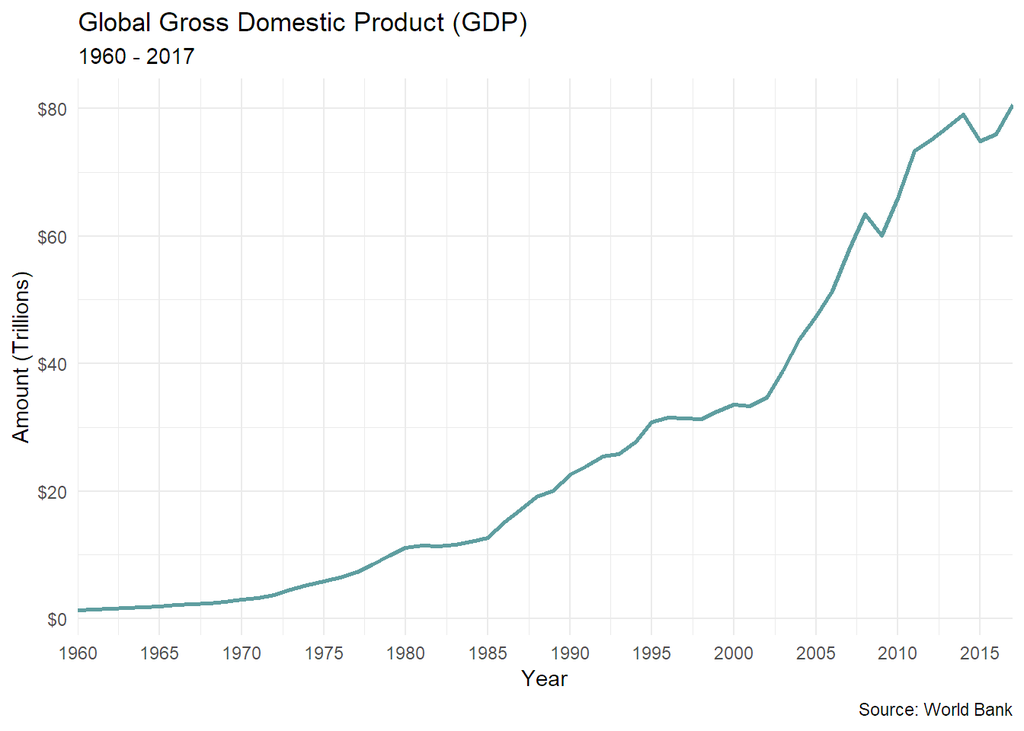

```r
debt_gdp %>%
  filter(country_name == "World") %>%
  # Scale large number
  mutate(amount = amount / 1000000000000) %>%
  ggplot(aes(x = year, y = amount)) +
    geom_line(color = "cadetblue", size = 1) +
    # Set custom breaks
    scale_x_continuous(breaks = seq(1960, 2017, by = 5), expand = c(0, 0)) +
    # Add dollar sign to values along y-axis
    scale_y_continuous(labels = scales::dollar) +
    labs(title = "Global Gross Domestic Product (GDP)",
         subtitle = "1960 - 2017",
         caption = "Source: World Bank",
         y = "Amount (Trillions)",
         x = "Year")
```

What does GDP look like for the United States, China, and the European Union?

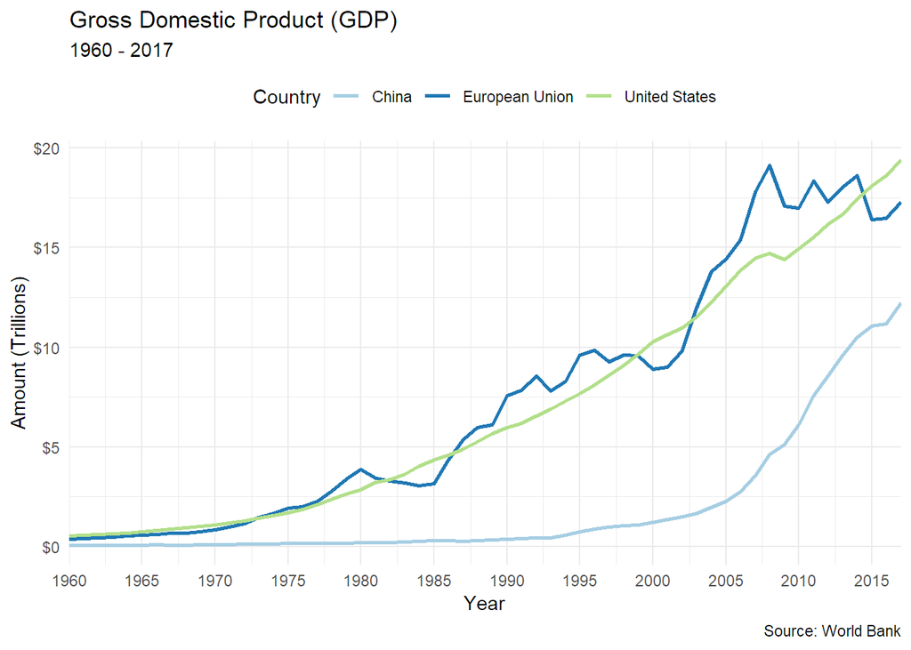

```r
# Vector of country names
countries <- c("United States", "China", "European Union")

# Visualize GDP
debt_gdp %>%
  filter(country_name %in% countries & indicator_name == "gdp") %>%
  # Scale large number
  mutate(amount = amount / 1000000000000) %>%
  ggplot(aes(x = year, y = amount, color = country_name)) +
    geom_line(size = 1) +
    scale_color_brewer(palette = "Paired") +
    # Set custom breaks
    scale_x_continuous(breaks = seq(1960, 2017, by = 5), expand = c(0, 0)) +
    guides(color = guide_legend(title = "Country")) +
    # Add dollar sign to values along y-axis
    scale_y_continuous(labels = scales::dollar) +
    labs(title = "Gross Domestic Product (GDP)",
         subtitle = "1960 - 2017",
         caption = "Source: World Bank",
         y = "Amount (Trillions)",
         x = "Year") +
    # Move legend to top
    theme(legend.position = "top")
```

### U.S. vs U.K.

Let’s compare the GDP between the United States and United Kingdom.

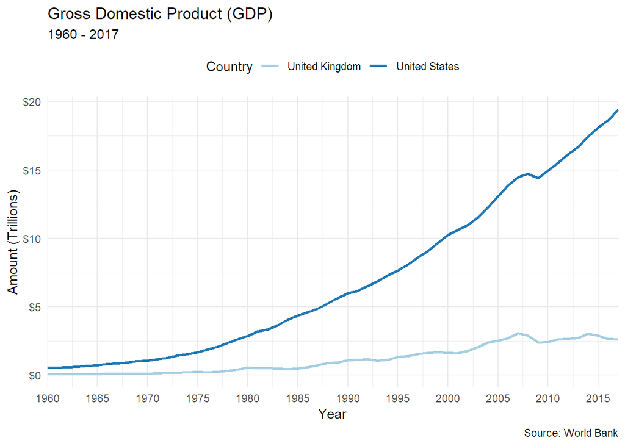

```r
# Vector of country names
western <- c("United States", "United Kingdom")

# Visualize GDP
debt_gdp %>%
  filter(country_name %in% western & indicator_name == "gdp") %>%
  # Scale large number
  mutate(amount = amount / 1000000000000) %>%
  ggplot(aes(x = year, y = amount, color = country_name)) +
    geom_line(size = 1) +
    scale_color_brewer(palette = "Paired") +
    # Set custom breaks
    scale_x_continuous(breaks = seq(1960, 2017, by = 5), expand = c(0, 0)) +
    guides(color = guide_legend(title = "Country")) +
    # Add dollar sign to values along y-axis
    scale_y_continuous(labels = scales::dollar) +
    labs(title = "Gross Domestic Product (GDP)",
         subtitle = "1960 - 2017",
         caption = "Source: World Bank",
         y = "Amount (Trillions)",
         x = "Year") +
    # Move legend to top
    theme(legend.position = "top")
```

How do the United States and United Kingdom compare on debt? Remember, the debt is measured as percent of GDP.

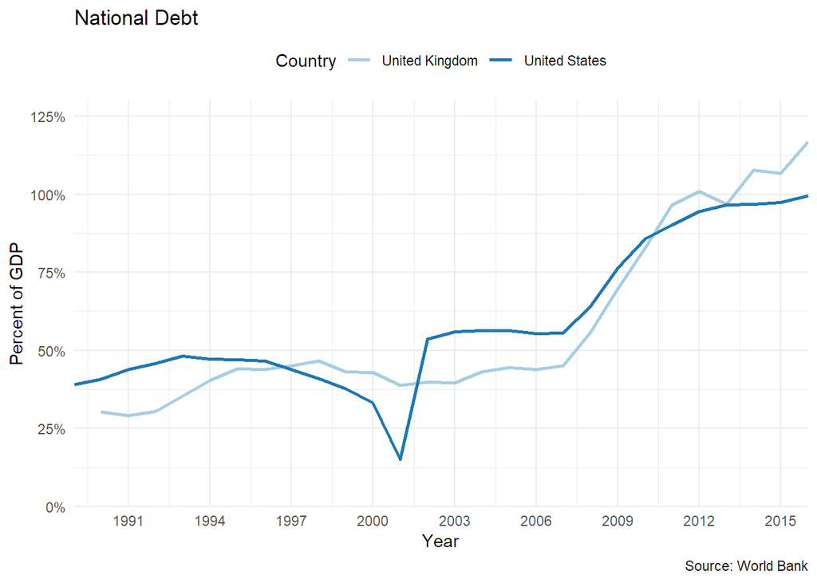

```r
# Visualize GDP
debt_gdp %>%
  filter(country_name %in% western & indicator_name == "debt") %>%
  mutate(amount = amount / 100) %>%
  ggplot(aes(x = year, y = amount, color = country_name)) +
    geom_line(size = 1) +
    scale_y_continuous(limits = c(0, 1.3), labels = scales::percent, expand = c(0, 0)) +
    # Set custom breaks
    scale_x_continuous(breaks = seq(1970, 2018, by = 3), expand = c(0, 0)) +
    scale_color_brewer(palette = "Paired") +
    guides(color = guide_legend(title = "Country")) +
    labs(title = "National Debt",
         caption = "Source: World Bank",
         y = "Percent of GDP",
         x = "Year") +
    # Move legend to top
    theme(legend.position = "top")
```